# PROJEKTE

## Paraqitja grafike

```r
leje <- read.csv(file.choose(), header = TRUE)
```

```r
head(leje)
```

|  | koha | Numri |
| --- | --- | --- |
| 1 | 2004-1 | 64 |
| 2 | 2004-2 | 304 |
| 3 | 2004-3 | 432 |
| 4 | 2004-4 | 691 |
| 5 | 2005-1 | 389 |
| 6 | 2005-2 | 881 |

```r
leje$koha <- as.Date(paste0(leje$koha, "-01")) # Konvertimi i kolonës së kohës në Date
```

```r
# Krijimi i objektit Time Series për të dhëna tremujore
myts <- ts(leje$Numri, start = 2004, frequency = 4)
```

```r
str(leje$date)
```

```r
# Kontrolli i serisë kohore
myts
```

```
##      Qtr1 Qtr2 Qtr3 Qtr4
## 2004   64  304  432  691
## 2005  389  881  443 1039
## 2006  303  557  521 1039
## 2007   40  173  232  550
## 2008  146  372  279  695
## 2009  695  695  305  510
## 2010  137  256  441 1011
## 2011  504  142  288  670
## 2012   19   18   37   73
## 2013   22   40   88  210
## 2014   58   39  122   51
## 2015   14   99   12   45
## 2016   65   98  145  147
## 2017  101  197  310  211
## 2018  221  270  343  360
## 2019  245  339  308  202
## 2020  184  209  262  306
## 2021  251  347  442  356
## 2022  397  339  269  415
## 2023  429  509  361  303
## 2024  311  354  354  317
## 2025  258  352
```

Tabela e mesiperme tregon paraqitjen e te dhenave tremujore

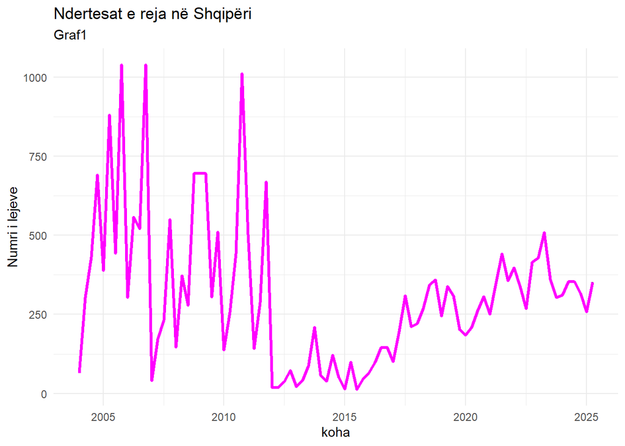

```r
library(ggplot2)
library(forecast)

# Vizualizimi bazik me ggplot2
autoplot(myts) +
  ggtitle("Ndertesat e reja në Shqipëri","Graf1") +
  xlab("koha") +
  ylab("Numri i lejeve") +
  theme_minimal() + geom_line(color = "magenta", size = 1.2)
```

Graf1 tregon paraqitjen e te dhenave ne seri kohore, vihet re se grafiku eshte i ndare ne dy periudha : *Periudha e pare 2004-2012* ku ne kete grafik te dhenat duken te crregullta pa trend dhe pa sezonalitet. *Periudha e dyte 2012-2025* ne kete periudh mund te dallojm nje trend ne rritje dhe sezonalitet, ky ndryshim mund te lidhet me faktore ekonomike dhe institucionale, si ndryshime ne politikat e urbanizimit, ciklet ekonomike, apo rritjen e aktivitetit ndertimor në vitet e fundit.

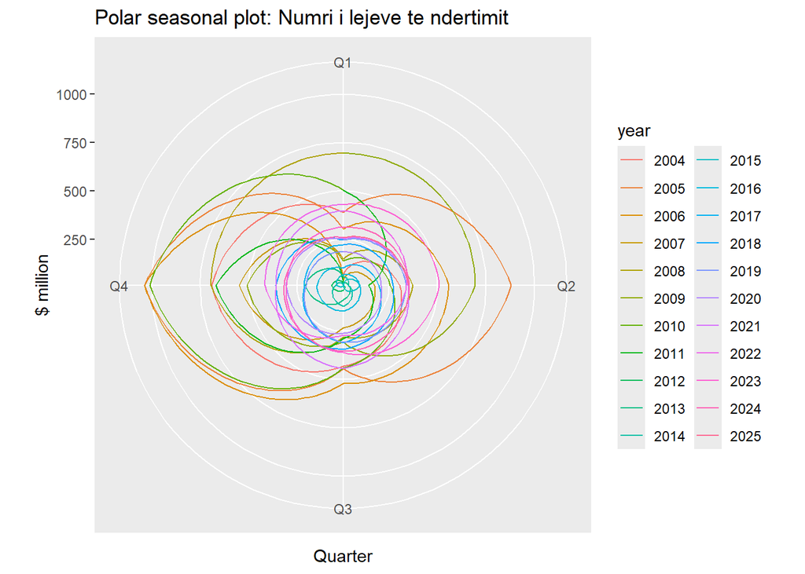

```r
ggseasonplot(myts, polar=TRUE) +
  ylab("$ million") +
  ggtitle("Polar seasonal plot: Numri i lejeve te ndertimit")
```

Ne kete grafik mund te shikojm lirshem se numri maksimal i lejeve te ndertimit eshte ne periushen 2006-2010 dhe numri minimal i lejeve te ndertimit eshte pas vitit 2013, kjo periudh duket sikur ka dhe nje trend rritjeje dhe sezonalitet.

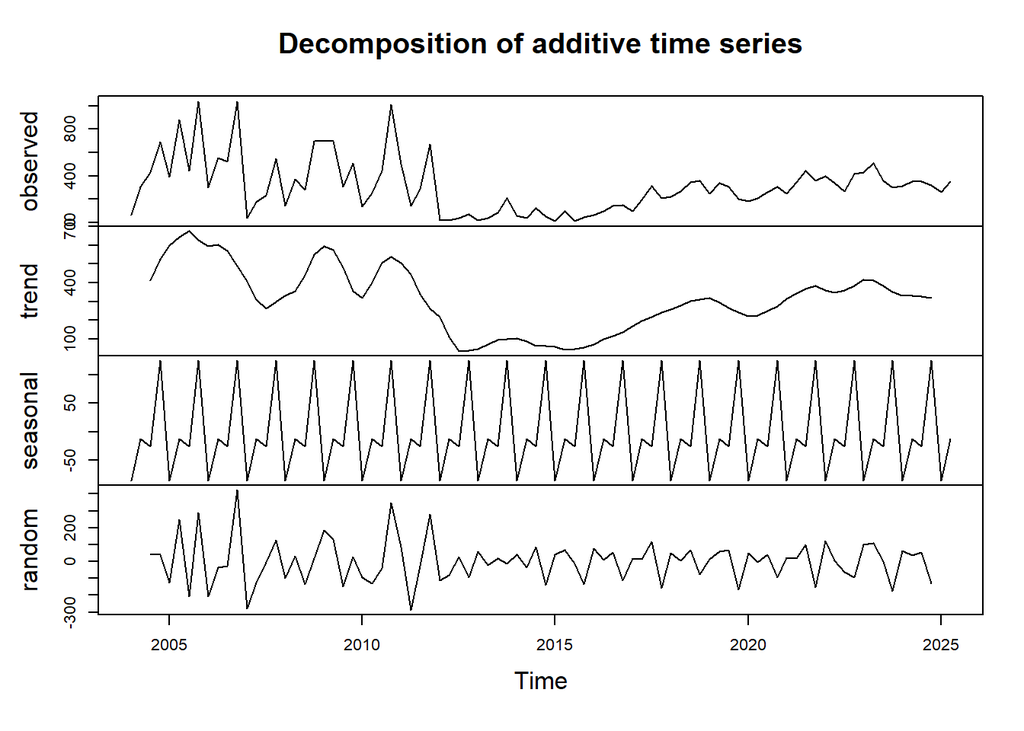

```r
#sezonaliteti trendi
decomp <- decompose(myts)
plot(decomp)
```

Grafiku i dekompozimit aditiv tregon se seria kohore e numrit të lejeve të ndërtimit nuk ka strukturë homogjene gjatë gjithë periudhës së analizuar. Në periudhën e parë, seria karakterizohet nga mungesa e trendit dhe sezonalitetit të qartë, ndërsa pas një momenti të caktuar kohor vërehet shfaqja e një trendi afatgjatë dhe e një sezonaliteti të rregullt. Kjo sugjeron ekzistencën e një ndryshimi strukturor në dinamikën e serisë kohore.

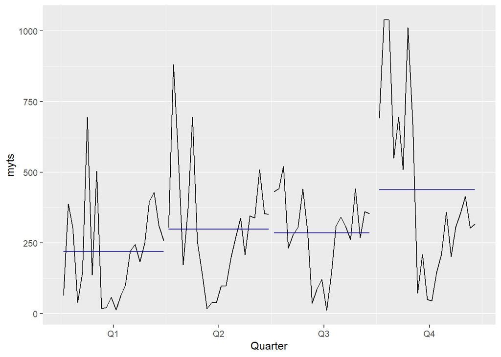

```r
 ggsubseriesplot(myts)
```

Grafiku paraqet vlerat e serisë kohore të numrit të lejeve të ndërtimit të grupuara sipas tremujorëve (Q1–Q4). Vijat blu përfaqësojnë mesataren e vlerave për secilin tremujor, ndërsa vija e zezë tregon vlerat individuale gjatë viteve. *Q1* (Tremujori i parë): Mesatarja është më e ulëta krahasuar me tremujorët e tjerë. Vërehen luhatje të mëdha dhe vlera relativisht të ulëta. Kjo sugjeron aktivitet ndërtimor më të dobët në fillim të vitit. *Q2* (Tremujori i dytë): Mesatarja rritet ndjeshëm krahasuar me Q1. Aktiviteti fillon të intensifikohet. Tregon fillimin e sezonit aktiv të ndërtimit. *Q3* (Tremujori i tretë): Mesatarja mbetet e lartë, por pak më e ulët se Q2. Ka ende variacion, por aktiviteti është i qëndrueshëm. Aktiviteti vazhdon gjatë verës. *Q4* (Tremujori i katërt) Mesatarja është më e larta nga të gjithë tremujorët. Vërehen edhe vlera ekstreme (pika shumë të larta). Aktiviteti kulmon në fund të vitit, ndoshta për shkak të mbylljes së projekteve apo procedurave administrative.